# Art Zaragoza_Neural_Networks_Customer_Churn_Project4_Full_code

Bank Churn Prediction

Neural Network model design to predict customer churn, optimizing for accuracy and computational efficiency.

## Executive Summary --------------------------------------------------------------------- Section

Is it possible to predict **which customers** are highly likely to leave the bank within 6 months? We will design a ANN to answer the question.

## Busines Needs Overview & Problem Statement -------------------------- Section

### Context & Objective

BUSINESS:

- Businesses like banks which provide service have to worry about problem of 'Customer Churn' i.e. customers leaving and joining another service provider. It is important to understand which aspects of the service influence a customer's decision in this regard. Management can concentrate efforts on improvement of service, keeping in mind these priorities.

ENGINEERING:

- You as a Data scientist with the bank need to build a neural network based classifier that can determine *whether a customer will leave the bank or not in the next 6 months*.

## Engineering ANN Design Strategy & General Approach ---------------------------------- Section

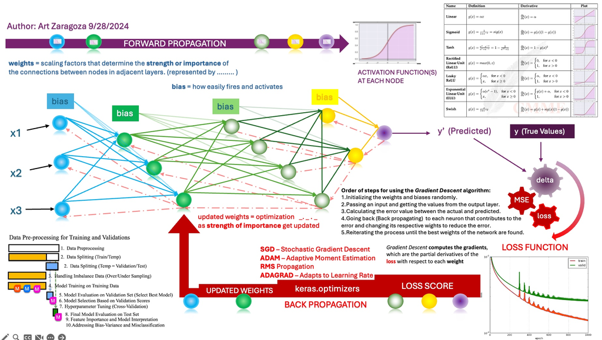

### Data Dictionary

| # | Feature | Description |
| --- | --- | --- |
| 1 | CustomerId | Unique ID which is assigned to each customer. |
| 2 | Surname | Last name of the customer. |
| 3 | CreditScore | It defines the credit history of the customer. |
| 4 | Geography | A customer’s location. |
| 5 | Gender | It defines the Gender of the customer. |
| 6 | Age | Age of the customer |
| 7 | Tenure | Number of years for which the customer has been with the bank. |
| 8 | NumOfProducts | Uumber of products that a customer has purchased through the bank. |
| 9 | Balance | Account balance |
| 10 | HasCrCard | It is a categorical variable which decides whether the customer has credit card or not. |
| 11 | EstimatedSalary | UEstimated salary |
| 12 | IsActiveMember | Is a categorical variable where custmomer is using bank products regularly, making transactions etc ) |
| 13 | Exited | Customer left the bank within six month. 0 = No or 1 = Yes ( Customer left the bank ) |

## Importing necessary libraries

```python
# Installing the libraries with the specified version.
!pip install tensorflow==2.15.0 scikit-learn==1.2.2 seaborn==0.13.1 matplotlib==3.7.1 numpy==1.25.2 pandas==2.0.3 imbalanced-learn==0.10.1 -q --user
```

**Note:** After running the above cell, please restart the notebook kernel/runtime (depending on whether you're using Jupyter Notebook or Google Colab) and then sequentially run all cells from the one below.

```python
# Libraries for reading and manipulating data
import pandas as pd
import numpy as np

# Libaries for data visualization
import matplotlib.pyplot as plt
import seaborn as sns

# Library to split data
from sklearn.model_selection import train_test_split

# Library to standardize the data
from sklearn.preprocessing import StandardScaler, LabelEncoder

# Import functions to build models
import tensorflow as tf
from tensorflow import keras
from keras import backend
from keras.models import Sequential
from keras.layers import Dense, Dropout

# Importing SMOTE
from imblearn.over_sampling import SMOTE

# Importing metrics
from sklearn.metrics import confusion_matrix,roc_curve,classification_report,recall_score

import random

# Library to avoid warnings
import warnings
warnings.filterwarnings("ignore")
```

```python
# Verifiyng installed versions. - EXTRA CREDIT
print('\nLibraries imported for Exploratory Data Analysis \n(EDA - Univariate and Multivariate):\n')
print("For Numerical Operations and Statistical Analysis of Data:")
print(" . Pandas version:", pd.__version__)
print(" . NumPy version:", np.__version__)
print("\nFor Visualization of Data: ")
print(" . Matplotlib version:", plt.rcParams['figure.figsize'])
print(" . Seaborn version:", sns.__version__)
print("\nFor Machine Learning Models:", tf.__version__)
print(" . Tensorflow version:", tf.__version__)
print(" . Keras version:", keras.__version__)
```

```
Libraries imported for Exploratory Data Analysis
(EDA - Univariate and Multivariate):

For Numerical Operations and Statistical Analysis of Data:
 . Pandas version: 2.2.2
 . NumPy version: 1.26.4

For Visualization of Data:
 . Matplotlib version: [6.4, 4.8]
 . Seaborn version: 0.13.2

For Machine Learning Models: 2.17.0
 . Tensorflow version: 2.17.0
 . Keras version: 3.4.1
```

```python
# GPU Processing Resources
gpu_info = !nvidia-smi
gpu_info = '\n'.join(gpu_info)
if gpu_info.find('failed') >= 0:
  print('Not connected to a GPU')
else:
  print(gpu_info)
```

```
Sat Oct 12 20:13:17 2024
+---------------------------------------------------------------------------------------+
| NVIDIA-SMI 535.104.05             Driver Version: 535.104.05   CUDA Version: 12.2     |
|-----------------------------------------+----------------------+----------------------+
| GPU  Name                 Persistence-M | Bus-Id        Disp.A | Volatile Uncorr. ECC |
| Fan  Temp   Perf          Pwr:Usage/Cap |         Memory-Usage | GPU-Util  Compute M. |
|                                         |                      |               MIG M. |
|=========================================+======================+======================|
|   0  Tesla T4                       Off | 00000000:00:04.0 Off |                    0 |
| N/A   45C    P8               9W /  70W |      0MiB / 15360MiB |      0%      Default |
|                                         |                      |                  N/A |
+-----------------------------------------+----------------------+----------------------+

+---------------------------------------------------------------------------------------+
| Processes:                                                                            |
|  GPU   GI   CI        PID   Type   Process name                            GPU Memory |
|        ID   ID                                                             Usage      |
|=======================================================================================|
|  No running processes found                                                           |
+---------------------------------------------------------------------------------------+
```

## Loading the dataset

```python
from google.colab import drive
drive.mount('/content/drive') # Mount drive
```

```python
ds = pd.read_csv("Churn.csv")  # Load raw dataset
```

## Data Overview

### View the first and last 5 rows of the dataset. - - Data Overview

```python
ds.head() # Top 5 rows of the dataset
```

|  | RowNumber | CustomerId | Surname | CreditScore | Geography | Gender | Age | Tenure | Balance | NumOfProducts | HasCrCard | IsActiveMember | EstimatedSalary | Exited |
| --- | --- | --- | --- | --- | --- | --- | --- | --- | --- | --- | --- | --- | --- | --- |
| 0 | 1 | 15634602 | Hargrave | 619 | France | Female | 42 | 2 | 0.00 | 1 | 1 | 1 | 101348.88 | 1 |
| 1 | 2 | 15647311 | Hill | 608 | Spain | Female | 41 | 1 | 83807.86 | 1 | 0 | 1 | 112542.58 | 0 |
| 2 | 3 | 15619304 | Onio | 502 | France | Female | 42 | 8 | 159660.80 | 3 | 1 | 0 | 113931.57 | 1 |
| 3 | 4 | 15701354 | Boni | 699 | France | Female | 39 | 1 | 0.00 | 2 | 0 | 0 | 93826.63 | 0 |
| 4 | 5 | 15737888 | Mitchell | 850 | Spain | Female | 43 | 2 | 125510.82 | 1 | 1 | 1 | 79084.10 | 0 |

```python
ds.tail() # Last 5 rows of the dataset
```

|  | RowNumber | CustomerId | Surname | CreditScore | Geography | Gender | Age | Tenure | Balance | NumOfProducts | HasCrCard | IsActiveMember | EstimatedSalary | Exited |
| --- | --- | --- | --- | --- | --- | --- | --- | --- | --- | --- | --- | --- | --- | --- |
| 9995 | 9996 | 15606229 | Obijiaku | 771 | France | Male | 39 | 5 | 0.00 | 2 | 1 | 0 | 96270.64 | 0 |
| 9996 | 9997 | 15569892 | Johnstone | 516 | France | Male | 35 | 10 | 57369.61 | 1 | 1 | 1 | 101699.77 | 0 |
| 9997 | 9998 | 15584532 | Liu | 709 | France | Female | 36 | 7 | 0.00 | 1 | 0 | 1 | 42085.58 | 1 |
| 9998 | 9999 | 15682355 | Sabbatini | 772 | Germany | Male | 42 | 3 | 75075.31 | 2 | 1 | 0 | 92888.52 | 1 |
| 9999 | 10000 | 15628319 | Walker | 792 | France | Female | 28 | 4 | 130142.79 | 1 | 1 | 0 | 38190.78 | 0 |

### View a random set of rows (seeded = reproducible). -- Data Overview

```python
ds.sample(n=7, random_state=42)
```

|  | RowNumber | CustomerId | Surname | CreditScore | Geography | Gender | Age | Tenure | Balance | NumOfProducts | HasCrCard | IsActiveMember | EstimatedSalary | Exited |
| --- | --- | --- | --- | --- | --- | --- | --- | --- | --- | --- | --- | --- | --- | --- |
| 6252 | 6253 | 15687492 | Anderson | 596 | Germany | Male | 32 | 3 | 96709.07 | 2 | 0 | 0 | 41788.37 | 0 |
| 4684 | 4685 | 15736963 | Herring | 623 | France | Male | 43 | 1 | 0.00 | 2 | 1 | 1 | 146379.30 | 0 |
| 1731 | 1732 | 15721730 | Amechi | 601 | Spain | Female | 44 | 4 | 0.00 | 2 | 1 | 0 | 58561.31 | 0 |
| 4742 | 4743 | 15762134 | Liang | 506 | Germany | Male | 59 | 8 | 119152.10 | 2 | 1 | 1 | 170679.74 | 0 |
| 4521 | 4522 | 15648898 | Chuang | 560 | Spain | Female | 27 | 7 | 124995.98 | 1 | 1 | 1 | 114669.79 | 0 |
| 6340 | 6341 | 15659064 | Salas | 790 | Spain | Male | 37 | 8 | 0.00 | 2 | 1 | 1 | 149418.41 | 0 |
| 576 | 577 | 15761986 | Obialo | 439 | Spain | Female | 32 | 3 | 138901.61 | 1 | 1 | 0 | 75685.97 | 0 |

### Shape of the dataset check. - - Data Overview

```python
ds.shape # Number of rows and columns in the training data
```

```
(10000, 14)
```

Observations:

- There are 10k rows with 14 columns in the Churn.csv.

### Data types check of the columns for the dataset. - - Data Overview

```python
ds.info() # Data types
```

```
<class 'pandas.core.frame.DataFrame'>
RangeIndex: 10000 entries, 0 to 9999
Data columns (total 14 columns):
 #   Column           Non-Null Count  Dtype
---  ------           --------------  -----
 0   RowNumber        10000 non-null  int64
 1   CustomerId       10000 non-null  int64
 2   Surname          10000 non-null  object
 3   CreditScore      10000 non-null  int64
 4   Geography        10000 non-null  object
 5   Gender           10000 non-null  object
 6   Age              10000 non-null  int64
 7   Tenure           10000 non-null  int64
 8   Balance          10000 non-null  float64
 9   NumOfProducts    10000 non-null  int64
 10  HasCrCard        10000 non-null  int64
 11  IsActiveMember   10000 non-null  int64
 12  EstimatedSalary  10000 non-null  float64
 13  Exited           10000 non-null  int64
dtypes: float64(2), int64(9), object(3)
memory usage: 1.1+ MB
```

Observations:

- There are 10k observations and 14 columns.
- 3 Columns are object datatype.
- 11 columns are numerical.
- There appears to be no missing data in all the columns as they match the size of the dataset.

### Statistical Summary Check. - - Data Overview

```python
# EXTRA CREDIT

# Note: Statistical information is obtained for numerical datatypes only, as shown below. There are only 11: (2) float64, (9) int64.
# Using a lamda function for rounding off to 2 digits the minimum, the average, and the maximum.
# Note: RowNumber & CustomerId statistics are not relevant and do not make sense other than in combination with other variables.

ds.describe().applymap(lambda x: round(x, 2)).T
```

|  | count | mean | std | min | 25% | 50% | 75% | max |
| --- | --- | --- | --- | --- | --- | --- | --- | --- |
| RowNumber | 10000.0 | 5000.50 | 2886.90 | 1.00 | 2500.75 | 5000.50 | 7500.25 | 10000.00 |
| CustomerId | 10000.0 | 15690940.57 | 71936.19 | 15565701.00 | 15628528.25 | 15690738.00 | 15753233.75 | 15815690.00 |
| CreditScore | 10000.0 | 650.53 | 96.65 | 350.00 | 584.00 | 652.00 | 718.00 | 850.00 |
| Age | 10000.0 | 38.92 | 10.49 | 18.00 | 32.00 | 37.00 | 44.00 | 92.00 |
| Tenure | 10000.0 | 5.01 | 2.89 | 0.00 | 3.00 | 5.00 | 7.00 | 10.00 |
| Balance | 10000.0 | 76485.89 | 62397.41 | 0.00 | 0.00 | 97198.54 | 127644.24 | 250898.09 |
| NumOfProducts | 10000.0 | 1.53 | 0.58 | 1.00 | 1.00 | 1.00 | 2.00 | 4.00 |
| HasCrCard | 10000.0 | 0.71 | 0.46 | 0.00 | 0.00 | 1.00 | 1.00 | 1.00 |
| IsActiveMember | 10000.0 | 0.52 | 0.50 | 0.00 | 0.00 | 1.00 | 1.00 | 1.00 |
| EstimatedSalary | 10000.0 | 100090.24 | 57510.49 | 11.58 | 51002.11 | 100193.91 | 149388.25 | 199992.48 |
| Exited | 10000.0 | 0.20 | 0.40 | 0.00 | 0.00 | 0.00 | 0.00 | 1.00 |

Observations:

### Missing Values Check. - - Data Overview

```python
ds.isnull().sum() #  Checking for missing values in the dataset.
```

|  | 0 |
| --- | --- |
| RowNumber | 0 |
| CustomerId | 0 |
| Surname | 0 |
| CreditScore | 0 |
| Geography | 0 |
| Gender | 0 |
| Age | 0 |
| Tenure | 0 |
| Balance | 0 |
| NumOfProducts | 0 |
| HasCrCard | 0 |
| IsActiveMember | 0 |
| EstimatedSalary | 0 |
| Exited | 0 |

**dtype:** int64

Observations:

- There appears to be no missing data in all the columns as they match the size of the dataset. (Just like with datatype output info above.)
- However, we must still check for `NaN` and `Not given` wherever these values are present, potentially affecting our calculations.

```python
# EXTRA CREDIT: FUNCTIONS AND HANDLING FOR 'NaN' and 'Not given'
# Check for NaN values in the dataset
nan_values = ds.isna().sum()
print("\n'NaN' Values in each column:\n", nan_values)

# Check for "Not given" (as a string) in the dataset
not_given_values = (ds == "Not given").sum()
print("\n'Not given' values in each column:\n", not_given_values)

# Replace "Not given" with NaN, so we can handle all missing data uniformly
# ds.replace("Not given", pd.NA, inplace=True)

# Check again after replacing 'Not given' with NaN
#print("\nAfter replacing 'Not given' with NaN, NaN values in each column:\n", ds.isna().sum())

# Optionally, you can handle the NaN values by dropping them or filling them with a default value
# For example, filling missing values with the median of each column
# ds.fillna(ds.median(), inplace=True)

# Print the dataset to ensure missing values are handled
# print("\nDataset after handling missing values:\n", ds)
```

```
'NaN' Values in each column:
 RowNumber          0
CustomerId         0
Surname            0
CreditScore        0
Geography          0
Gender             0
Age                0
Tenure             0
Balance            0
NumOfProducts      0
HasCrCard          0
IsActiveMember     0
EstimatedSalary    0
Exited             0
dtype: int64

'Not given' values in each column:
 RowNumber          0
CustomerId         0
Surname            0
CreditScore        0
Geography          0
Gender             0
Age                0
Tenure             0
Balance            0
NumOfProducts      0
HasCrCard          0
IsActiveMember     0
EstimatedSalary    0
Exited             0
dtype: int64
```

Observations:

- There are no NaN nor Not Given entries in our dataset.

### Duplicates check. - - Data Overview

```python
ds.duplicated().sum() # Check for duplicate values in the data
```

```
0
```

### Unique values check for each of the column. - - Data Overview

```python
ds.nunique() # Number of Unique Values (Groups)
```

|  | 0 |
| --- | --- |
| RowNumber | 10000 |
| CustomerId | 10000 |
| Surname | 2932 |
| CreditScore | 460 |
| Geography | 3 |
| Gender | 2 |
| Age | 70 |
| Tenure | 11 |
| Balance | 6382 |
| NumOfProducts | 4 |
| HasCrCard | 2 |
| IsActiveMember | 2 |
| EstimatedSalary | 9999 |
| Exited | 2 |

**dtype:** int64

Observations:

- These two numeric columns and this string column do not provide insights and could be candidates for dropping: RowNumber, CustomerId and Surname.
- The following columns have large variations of values: CreditScore, Age, Tenure, Balance and EstimatedSalary.

### Distribution of Targeted column (Exited = 1) - - Data Overview

```python
ds["Exited"].value_counts(1)
```

| Exited | proportion |
| --- | --- |
| 0 | 0.7963 |
| 1 | 0.2037 |

**dtype:** float64

Observations:

- Approximately 20% of all Customers have exited.
- 20% is unacceptably high for any business.

```python
ds['Geography'].value_counts()# Data frequency categories.
```

| Geography | count |
| --- | --- |
| France | 5014 |
| Germany | 2509 |
| Spain | 2477 |

**dtype:** int64

Observations:

- 50% of Customers are from France and the remaining half are equally divided between Germany and Spain.

Recommendations:

- Right off the bat, bank offerings must include services in three languages: French, German and Spanish.
- There are twice as many French customers, therefore the marketing and customer support and customer retention budgets should reflect the same.
- Bots or AI assistants should provide culture and language sensitivity to reflect customer's distribution.
- Important: EU AI Act applies to all 3 countries and the bank must follow these regulations with strict compliance.

```python
ds['Gender'].value_counts() # Data frequency categories.
```

| Gender | count |
| --- | --- |
| Male | 5457 |
| Female | 4543 |

**dtype:** int64

Observations:

- The number of Males and Females are about the same, however there are about 1,000 more males than females or 10% **more** of all Customers are males.

Recommendations:

- Great opportunity to increase adoption of services by targeting the female population to enroll in the bank.
- It is crucial that the marketing advertising and customer services are gender sensitive to ensure respect and recruitment towards both genders, but more so towards females.

```python
ds['Tenure'].value_counts() # Data frequency categories.
```

| Tenure | count |
| --- | --- |
| 2 | 1048 |
| 1 | 1035 |
| 7 | 1028 |
| 8 | 1025 |
| 5 | 1012 |
| 3 | 1009 |
| 4 | 989 |
| 9 | 984 |
| 6 | 967 |
| 10 | 490 |
| 0 | 413 |

**dtype:** int64

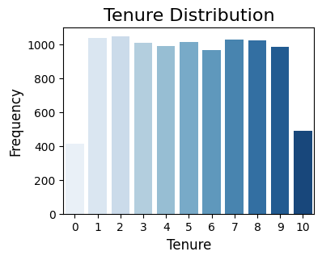

```python
# Set the figure size and plot the bar plot
plt.figure(figsize=(4,3))
sns.countplot(x='Tenure', data=ds, palette='Blues')

# Adding labels and title
plt.title('Tenure Distribution', fontsize=16)
plt.xlabel('Tenure', fontsize=12)
plt.ylabel('Frequency', fontsize=12)

# Show the plot
plt.show()
```

Observations:

- Customers are mostly distributed between 1 - 9 years of Tenure.
- For each year of Tenure, the number of Customers floats around 900 - 1100.

```python
ds['NumOfProducts'].value_counts() # Data frequency categories.
```

| NumOfProducts | count |
| --- | --- |
| 1 | 5084 |
| 2 | 4590 |
| 3 | 266 |
| 4 | 60 |

**dtype:** int64

Observations:

- The majority of Customers use 1 or 2 bank products.
- About half of Customers use one product and less than half use two.
- An extremely small number uses 3 (266 Customers) and only 60 uses 4 services.

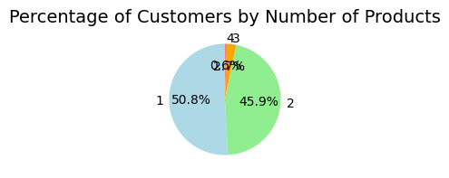

```python
import matplotlib.pyplot as plt

# Get the frequency of each category in 'NumOfProducts'
product_counts = ds['NumOfProducts'].value_counts()

# Plot pie chart
plt.figure(figsize=(2, 2))  # Set the figure size
plt.pie(product_counts, labels=product_counts.index, autopct='%1.1f%%', startangle=90, colors=['lightblue', 'lightgreen', 'orange', 'lightcoral'])

# Adding title
plt.title('Percentage of Customers by Number of Products', fontsize=14)

# Show the pie chart
plt.show()
```

Observations:

- 1/2 of all Customers are using one of the bank's offerings.
- Less than the remaining half are using 2 offerings.
- Very few use 3 and a handful uses all 4 offerings.

Recommendations:

- Those that have one of the offerings are best target candidates to get 2 offerings due to familiarity and experience.
- Customer Satisfaction research should be considered to prevent nearly 1/2 or 46% of all customers from dropping one of the 2 offerings. Retention is crucial for revenue stability.

```python
ds['HasCrCard'].value_counts() # Data frequency categories.
```

| HasCrCard | count |
| --- | --- |
| 1 | 7055 |
| 0 | 2945 |

**dtype:** int64

Observations:

Recommendations:

- Target Customers without credit cards to increase conversion.
- Increase incentives for Customers without credit card.
- Increase Customer's credit card retention by customer satisfaction research.
- Design offers with attractive balance transfers to those Customers with other institutions credit cards.
- Determine which Customers with credit cards are at risk of loosing their credit card services to ensure they remain revenue-worthy. Ensure is a win-win for both the customer and the bank.

```python
ds['IsActiveMember'].value_counts() # Data frequency categories.
```

| IsActiveMember | count |
| --- | --- |
| 1 | 5151 |
| 0 | 4849 |

**dtype:** int64

Observations:

- Only about half of Customers are actively conducting transactions or using bank products.
- This is catastrophic. Deeper research is needed here to understand the root causes.

Recommendations:

- Provide a budget to research contributing factors for the lack of resonable transactions.
- Is there an "average" baseline of ideal or optimum Customers average transactions meetrics? If not, one MUST be establish ASAP.
- Once this baseline is established, it can be used as a treshold metric and an alarm or "signal" should be triggered for all Customers NOT crossing it.

```python
ds['Exited'].value_counts()  # Data frequency categories.
```

| Exited | count |
| --- | --- |
| 0 | 7963 |
| 1 | 2037 |

**dtype:** int64

Observations:

Recommendations:

- A predictive NN model should be designed to anticipate Customer trends and provide opportunities to interject before is too late. (This project. :-) )
- Daily runs in production should provide 'alerts' whenever patterns are detected or treshold metrics are crossed with production or unseen data.
- The predictive model should be fine-tuned regularly to incorporate additional data values accounting for the preventative-actions and measure both their exit-recurrence effectiveness to the business and the efficiency of the model predictions.
- Transparency of Customer's Privacy protections should be auditable and test-demonstrated frequently as this model is predictive and could cause incorrect, even catastrophic communications to Customers and Regulators when biased.

```python
(ds['Balance'] == 0).sum() # Number of Customers with 0 Balance in their accounts.
```

```
3617
```

Observations:

- A fairly large number of Customers are keeping a 0 balance in their accounts.
- More precisely 3,617 out of 10,000 (36.2%) or a third of all customers. Recommendations:
- More research is required in this area. A budget for research should be added to understand contributing factors and corrective actions, RCCAs (Root Cause Corrective Actions).
- Incentives should be studied to provide value-add to these customers as a win-win for them and for the bank.

```python
ds = ds.drop(['RowNumber', 'CustomerId', 'Surname'], axis=1) # RowNumber, CustomerId and Surname are all unique therefore these columns can be dropped
```

Recommendation:

- There's no need to keep RowNumber, CustomerID and Surname data for statistical analysis nor for our purposes. These can be dropped.

```python
print("\nRowNumber, CustomerID and Surname data were dropped and Gender and Geography are Object datatypes.", "\nRemaining numeric data:\n")
ds.describe().applymap(lambda x: round(x, 2)).T # Gender & Geography not listed as they are Object datatype as the remaining columns not listed below.
```

```
RowNumber, CustomerID and Surname data were dropped and Gender and Geography are Object datatypes.
Remaining numeric data:
```

|  | count | mean | std | min | 25% | 50% | 75% | max |
| --- | --- | --- | --- | --- | --- | --- | --- | --- |
| CreditScore | 10000.0 | 650.53 | 96.65 | 350.00 | 584.00 | 652.00 | 718.00 | 850.00 |
| Age | 10000.0 | 38.92 | 10.49 | 18.00 | 32.00 | 37.00 | 44.00 | 92.00 |
| Tenure | 10000.0 | 5.01 | 2.89 | 0.00 | 3.00 | 5.00 | 7.00 | 10.00 |
| Balance | 10000.0 | 76485.89 | 62397.41 | 0.00 | 0.00 | 97198.54 | 127644.24 | 250898.09 |
| NumOfProducts | 10000.0 | 1.53 | 0.58 | 1.00 | 1.00 | 1.00 | 2.00 | 4.00 |
| HasCrCard | 10000.0 | 0.71 | 0.46 | 0.00 | 0.00 | 1.00 | 1.00 | 1.00 |
| IsActiveMember | 10000.0 | 0.52 | 0.50 | 0.00 | 0.00 | 1.00 | 1.00 | 1.00 |
| EstimatedSalary | 10000.0 | 100090.24 | 57510.49 | 11.58 | 51002.11 | 100193.91 | 149388.25 | 199992.48 |
| Exited | 10000.0 | 0.20 | 0.40 | 0.00 | 0.00 | 0.00 | 0.00 | 1.00 |

Observations:

## Exploratory Data Analysis - EDA --------------------------------------------- Section

### Univariate Analysis - EDA

```python
# Function to plot a boxplot and a histogram along the same scale.


def histogram_boxplot(data, feature, figsize=(12, 7), kde=False, bins=None):
    """
    Boxplot and histogram combined

    data: dataframe
    feature: dataframe column
    figsize: size of figure (default (12,7))
    kde: whether to show the density curve (default False)
    bins: number of bins for histogram (default None)
    """
    f2, (ax_box2, ax_hist2) = plt.subplots(
        nrows=2,  # Number of rows of the subplot grid= 2
        sharex=True,  # x-axis will be shared among all subplots
        gridspec_kw={"height_ratios": (0.25, 0.75)},
        figsize=figsize,
    )  # creating the 2 subplots
    sns.boxplot(
        data=data, x=feature, ax=ax_box2, showmeans=True, color="violet"
    )  # boxplot will be created and a star will indicate the mean value of the column
    sns.histplot(
        data=data, x=feature, kde=kde, ax=ax_hist2, bins=bins, palette="winter"
    ) if bins else sns.histplot(
        data=data, x=feature, kde=kde, ax=ax_hist2
    )  # For histogram
    ax_hist2.axvline(
        data[feature].mean(), color="green", linestyle="--"
    )  # Add mean to the histogram
    ax_hist2.axvline(
        data[feature].median(), color="black", linestyle="-"
    )  # Add median to the histogram
```

```python
# Function to create labeled barplots


def labeled_barplot(data, feature, perc=False, n=None):
    """
    Barplot with percentage at the top

    data: dataframe
    feature: dataframe column
    perc: whether to display percentages instead of count (default is False)
    n: displays the top n category levels (default is None, i.e., display all levels)
    """

    total = len(data[feature])  # length of the column
    count = data[feature].nunique()
    if n is None:
        plt.figure(figsize=(count + 1, 5))
    else:
        plt.figure(figsize=(n + 1, 5))

    plt.xticks(rotation=90, fontsize=15)
    ax = sns.countplot(
        data=data,
        x=feature,
        palette="Paired",
        order=data[feature].value_counts().index[:n].sort_values(),
    )

    for p in ax.patches:
        if perc == True:
            label = "{:.1f}%".format(
                100 * p.get_height() / total
            )  # percentage of each class of the category
        else:
            label = p.get_height()  # count of each level of the category

        x = p.get_x() + p.get_width() / 2  # width of the plot
        y = p.get_height()  # height of the plot

        ax.annotate(
            label,
            (x, y),
            ha="center",
            va="center",
            size=12,
            xytext=(0, 5),
            textcoords="offset points",
        )  # annotate the percentage

    plt.show()  # show the plot
```

#### Observations on CreditScore

```python
# EXTRA CREDIT - Function expanded to include Mean and Median to be displayed on plot.
def histogram_boxplot(data, feature, figsize=(12, 7), kde=False, bins=None):
    """
    Boxplot and histogram combined with the mean value displayed on the histogram.

    data: dataframe
    feature: dataframe column
    figsize: size of figure (default (12,7))
    kde: whether to show the density curve (default False)
    bins: number of bins for histogram (default None)
    """
    f2, (ax_box2, ax_hist2) = plt.subplots(
        nrows=2,  # Number of rows of the subplot grid= 2
        sharex=True,  # x-axis will be shared among all subplots
        gridspec_kw={"height_ratios": (0.25, 0.75)},
        figsize=figsize,
    )  # creating the 2 subplots

    # Create the boxplot
    sns.boxplot(
        data=data, x=feature, ax=ax_box2, showmeans=True, color="orange"
    )  # Boxplot with the mean indicated

    # Create the histogram
    sns.histplot(
        data=data, x=feature, kde=kde, ax=ax_hist2, bins=bins, color="skyblue"
    ) if bins else sns.histplot(
        data=data, x=feature, kde=kde, ax=ax_hist2
    )  # Histogram

    # Calculate mean and median
    mean_val = data[feature].mean()
    median_val = data[feature].median()

    # Add mean and median lines to the histogram
    ax_hist2.axvline(mean_val, color="green", linestyle="--", label=f'Mean: {mean_val:.2f}')
    ax_hist2.axvline(median_val, color="black", linestyle="-", label=f'Median: {median_val:.2f}')

    # Display the value of the mean on the plot
    ax_hist2.text(mean_val, ax_hist2.get_ylim()[1] * 0.8, f'Mean: {mean_val:.2f}',
                  color='green', fontsize=12, ha='center')

    # Optionally, display the value of the median on the plot
    ax_hist2.text(median_val, ax_hist2.get_ylim()[1] * 0.7, f'Median: {median_val:.2f}',
                  color='black', fontsize=12, ha='center')

    # Add a legend to the plot
    ax_hist2.legend()
```

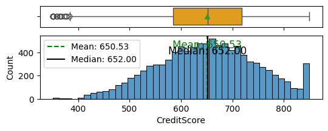

```python
histogram_boxplot(ds, 'CreditScore', figsize=(6, 2)) # Histogram_boxplot for Credit Score.
```

Observations:

Recommendations:

- Data preprocessing-handling candidates are both the outliers and Customers contributing to the band with highest credit score.

#### Observations on Age

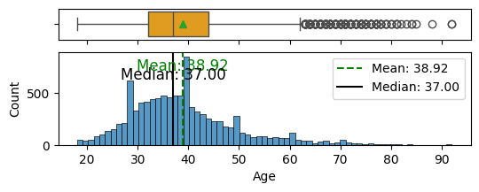

```python
histogram_boxplot(ds, 'Age', figsize=(6, 2)) # Histogram_boxplot for Age.
```

[output not shown]

[figure not shown]

```python
import seaborn as sns
import matplotlib.pyplot as plt
import pandas as pd

# Define the age ranges and generation labels
generation_labels = ['Silent Generation', 'Baby Boomers', 'Generation X', 'Millennials', 'Generation Z', 'Generation Alpha']
bins = [0, 11, 27, 43, 59, 78, 96]

# Create a new column for the generations
ds['Generation'] = pd.cut(ds['Age'], bins=bins, labels=generation_labels, right=False)

# Count the number of customers in each generation
generation_counts = ds['Generation'].value_counts()

# Sort the counts according to the defined generation labels
generation_counts = generation_counts.reindex(generation_labels)

# Fill missing values with zero if any generations are not present in the data
generation_counts = generation_counts.fillna(0)

# Calculate total customers
total_customers = generation_counts.sum()

# Debug: Print generation counts to verify values
print(generation_counts)

# Create a horizontal bar plot
plt.figure(figsize=(5, 2.5))
sns.barplot(x=generation_counts.values, y=generation_counts.index, palette='Set1')

# Add labels and title
plt.xlabel('Number of Customers')
plt.ylabel('Generation')
plt.title("Bank's Customer Distribution by Generation")

# Set x-axis limits to ensure proper display of larger values
plt.xlim(0, generation_counts.max() + 500)  # Adjust limit based on your data

# Add actual numbers and percentages on top of the bars
for index, value in enumerate(generation_counts.values):
    percentage = (value / total_customers) * 100
    plt.text(value, index, f'{int(value)} ({percentage:.1f}%)', va='center', fontsize=10, fontweight='bold')

plt.tight_layout()
plt.show()
```

| Generation | Birth Years | Age Range (2024) | Bank Attitude | Credit Card Attitude |
| --- | --- | --- | --- | --- |
| Generation Alpha | 2013–2025 | 0–11 | Not yet developed | Not yet developed |
| Generation Z | 1997–2012 | 12–27 | Prefer digital banking solutions | Value rewards and low fees |
| Millennials (Gen Y) | 1981–1996 | 28–43 | Favor banks with ethical practices | Use credit cards for convenience and rewards |
| Generation X | 1965–1980 | 44–59 | Traditional banking preferences | Prefer stability and reliability |
| Baby Boomers | 1946–1964 | 60–78 | Trust in established banks | Use credit cards primarily for emergencies |
| Silent Generation | 1928–1945 | 79–96 | Conservative with financial choices | Prefer cash and debit cards |

Observations:

Important Notes on Age:

Recommendations: